# Exercise 1 Team 0

# task1:

Download methylation call files from GEO. These files are readable by methlKit using default methRead arguments.

```r
download.file("https://www.ncbi.nlm.nih.gov/geo/download/?acc=GSM919990&format=file&file=GSM919990%5FIDH%2Dmut%5F1%5FmyCpG%2Etxt%2Egz",
              destfile = "IDH1_rep1.cpg.txt")
download.file("https://www.ncbi.nlm.nih.gov/geo/download/?acc=GSM919991&format=file&file=GSM919991%5FIDH%5Fmut%5F2%5FmyCpG%2Etxt%2Egz",
              destfile = "IDH1_rep2.cpg.txt")
download.file("https://www.ncbi.nlm.nih.gov/geo/download/?acc=GSM919982&format=file&file=GSM919982%5FNBM%5F1%5FmyCpG%2Etxt%2Egz",
              destfile = "NBM_rep1.cpg.txt")
download.file("https://www.ncbi.nlm.nih.gov/geo/download/?acc=GSM919984&format=file&file=GSM919984%5FNBM%5F2%5FRep1%5FmyCpG%2Etxt%2Egz",
              destfile = "NBM_rep2.cpg.txt")
```

read files as methylKit objects

```r
library(methylKit)
file.list=list("IDH1_rep1.cpg.txt.gz","IDH1_rep2.cpg.txt.gz",
               "NBM_rep1.cpg.txt.gz","NBM_rep2.cpg.txt.gz")
myobj=methRead(file.list,
           sample.id=list("idh1","idh2","nbm1","nbm2"),
           assembly="hg18",
           treatment=c(1,1,0,0),
           context="CpG"
           )
```

```
Read 10.3% of 2331753 rows
Read 36.5% of 2331753 rows
Read 84.9% of 2331753 rows
Read 2331753 rows and 7 (of 7) columns from 0.100 GB file in 00:00:06

Read 64.6% of 2755434 rows
Read 2755434 rows and 7 (of 7) columns from 0.118 GB file in 00:00:03
```

# task 2

Find differentially methylated cytosines. Use chr1 and chr2 only if you need to save time. You can subset it after you download the files either in R or unix. The files are for hg18 assembly of human genome.

first use `unite()` then do differential methylation

```r
meth=unite(myobj, destrand=FALSE)
# subset for chr1
meth=meth[meth$chr == "chr1",]
dm.lr=calculateDiffMeth(meth,overdispersion = "MN",test ="Chisq")
```

```
two groups detected:
 will calculate methylation difference as the difference of
treatment (group: 1) - control (group: 0)
```

let’s see what is in the object

```r
head(dm.lr)
```

```
methylDiff object with 6 rows
--------------
   chr  start    end strand    pvalue    qvalue   meth.diff
1 chr1    497    497      + 0.7899279 0.8602991  -4.3087558
2 chr1    525    525      + 0.4403096 0.7417248  -2.6019900
3 chr1    542    542      + 0.9734312 0.8602991   0.1165501
4 chr1 557070 557070      - 0.5567218 0.8319200  -7.9095210
5 chr1 557103 557103      - 0.4493419 0.7485025 -10.2596054
6 chr1 705253 705253      - 0.1561088 0.4438380  -4.7179487
--------------
sample.ids: idh1 idh2 nbm1 nbm2
destranded FALSE
assembly: hg18
context: CpG
treament: 1 1 0 0
resolution: base
```

# task 3

Describe the differential methylation trend, what is the main effect ? Most of the differential methylation is hyper-methylation compared to bone marrows

```r
diffs=getMethylDiff(dm.lr,qvalue = 0.01,difference = 10)
dim(diffs)
```

```
[1] 3968    7
```

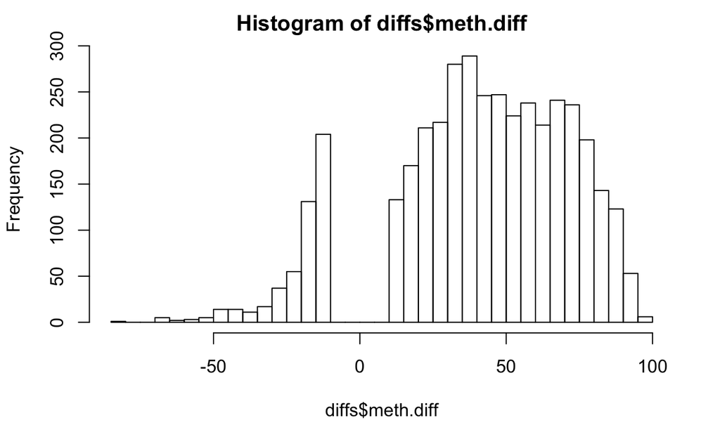

```r
hist(diffs$meth.diff,breaks=50)
```

There are many different ways to visualize this, volcano plots, ideograms etc.

# task 4

Annotate differentially methylated cytosines (DMCs) promoter/intron/exon ? Downloaded hg18 refseq BED file UCSC genome browser.

```r
library(genomation)
genes=readTranscriptFeatures("refseq.hg18.bed")
```

```
Reading the table...
Calculating intron coordinates...
Calculating exon coordinates...
Calculating TSS coordinates...
Calculating promoter coordinates...
Outputting the final GRangesList...
```

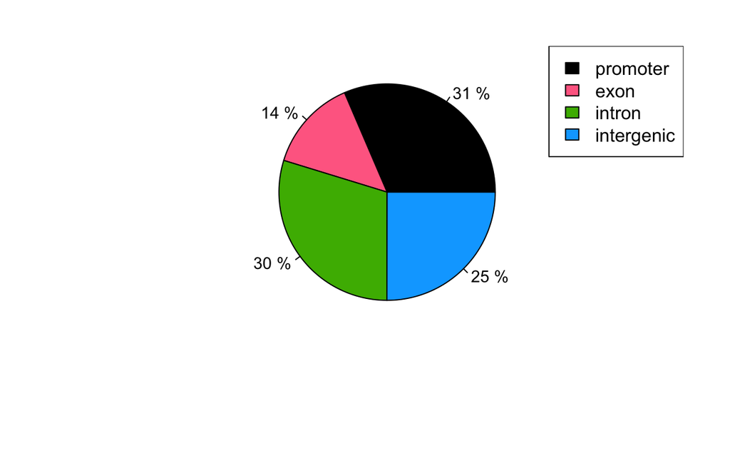

```r
annot=annotateWithGeneParts(as(diffs,"GRanges"),genes)
# we want to use genomation function plotTargetAnnotation
genomation::plotTargetAnnotation(annot)
```

# task 5

Which genes are the nearest to DMCs ? Can you do gene set analysis either in R or via web-based tools ?

There are a million ways to do this. One easy way is getting nearest TSS via genomation/methylKit functions and pasting the gene names to gprofiler or david web-app.

Now, using genomation function `getAssociationWithTSS()` we can get the nearest TSS for each differentially methylated CpG.

```r
###
TSSasoc=getAssociationWithTSS(annot)
# gene names for each DMC
head(unique(TSSasoc$feature.name))
```

```
[1] "NR_026874"    "NR_122045"    "NM_152486"    "NM_015658"
[5] "NM_198317"    "NM_001160184"
```

If we have the gene names we have a bunch of options, let’s try [gProfileR](https://cran.r-project.org/web/packages/gProfileR/) package which is an R interface to [g:Profiler](https://biit.cs.ut.ee/gprofiler/) web app.

```r
library(gProfileR)
res=gprofiler(query=unique(TSSasoc$feature.name),
          organism = "hsapiens")
res[res$significant==TRUE,c(3,9,10,12)]
```

|  | p.value | term.id | domain | term.name |
| --- | --- | --- | --- | --- |
| 1 | 1.69e-02 | GO:0034762 | BP | regulation of transmembrane transport |
| 2 | 2.17e-02 | GO:0034765 | BP | regulation of ion transmembrane transport |
| 3 | 1.04e-02 | GO:0006928 | BP | movement of cell or subcellular component |
| 4 | 1.72e-02 | GO:0097485 | BP | neuron projection guidance |
| 5 | 4.36e-03 | GO:0061564 | BP | axon development |
| 6 | 5.01e-03 | GO:0007409 | BP | axonogenesis |
| 7 | 1.50e-02 | GO:0007411 | BP | axon guidance |
| 8 | 3.97e-02 | GO:0014706 | BP | striated muscle tissue development |
| 9 | 5.65e-07 | GO:0032502 | BP | developmental process |
| 10 | 7.52e-04 | GO:0048869 | BP | cellular developmental process |

[output cut: 457 more lines]

Even an easier way is to use, rGREAT package. This first associates DMCs to genes and runs gene set analysis. This is an interface to [GREAT](http://great.stanford.edu) web app.

```r
library(rGREAT)
bed=getData(diffs)[,1:3]
job = submitGreatJob(bed,species = "hg18",version="2.0.2")
tb = getEnrichmentTables(job,category="Pathway Data")
names(tb)
```

```
[1] "PANTHER Pathway" "Pathway Commons" "BioCyc Pathway"
[4] "MSigDB Pathway"
```

```r
tb[[1]][1:2, ]
```

|  | ID | name | Binom_Genome_Fraction | Binom_Expected | Binom_Observed_Region_Hits | Binom_Fold_Enrichment | Binom_Region_Set_Coverage | Binom_Raw_PValue | Binom_Adjp_BH | Hyper_Total_Genes | Hyper_Expected | Hyper_Observed_Gene_Hits | Hyper_Fold_Enrichment | Hyper_Gene_Set_Coverage | Hyper_Term_Gene_Coverage | Hyper_Raw_PValue | Hyper_Adjp_BH |
| --- | --- | --- | --- | --- | --- | --- | --- | --- | --- | --- | --- | --- | --- | --- | --- | --- | --- |
| 1 | P04394 | Thyrotropin-releasing hormone receptor signaling pathway | 0.006730319 | 26.22805 | 123 | 4.689635 | 0.03156274 | 4.076776e-43 | 5.707486e-41 | 57 | 3.115849 | 7 | 2.246579 | 0.007261411 | 0.1228070 | 0.03493784 | 0.3062051 |
| 2 | P04391 | Oxytocin receptor mediated signaling pathway | 0.006086583 | 23.71941 | 111 | 4.679711 | 0.02848345 | 5.827755e-39 | 4.079429e-37 | 55 | 3.006521 | 7 | 2.328272 | 0.007261411 | 0.1272727 | 0.02942524 | 0.3062051 |